# MATH 421 - Final Presentation

December 15, 2018

## Introduction

- Data: "2017 Iditarod Trail Sled Dog Race" from Kaggle https://www.kaggle.com/iditarod/iditarod-race
- I am predicting whether or not a participant is a "Rookie" (first time participant) or a "Veteran" (a returning participant).
- Not necessarily the most useful target variable, but it would be helpful if someone were to bet on a participant, and are choosing between a rookie or veteran. It was also chosed out of curiosity on my part.
- There does not appear to be any other works on this problem.
- 1146 observations

## My Variables

- Number - Bib Number
- Name - Musher's Name
- Status - Status in the Race
- Country - Country of Origin
- Checkpoint - Checkpoint Name
- Latitude - location of checkpoint
- Longitude - location of checkpoint
- Distance - distance in miles from last checkpoint
- Time - time in hours from departure at the last checkpoint,
- Speed - average speed in miles per hour
- Arrival Date

## My Variables (cont'd)

- Arrival Time (Removed)
- Arrival Dogs - number of dogs at arrival
- Elapsed Time - layover time at the checkpoint
- Departure Date
- Departure Time (Removed)
- Departure Dogs - Number of dogs at departure

## Recoded Variables

- Name: 72 levels, changed to Male and Female
- Checkpoint: 17 levels, changed to Early, Middle, and End
- Arrival.Date: 14 levels, changed to Sunday-Saturday
- Departure.Date: 14 levels, changed to Sunday-Saturday

## Replacing Missing Values

Missing/blank Arrival.Date and Departure.Date were recoded as "Sunday"

- "Mean Impute" - replaced all missing numerics with means
- MedianImpute
- knnImpute

## Encoding

Ran models:

- without encoding
- with dummy encoding
- with numeric encoding

## Examples of graphs

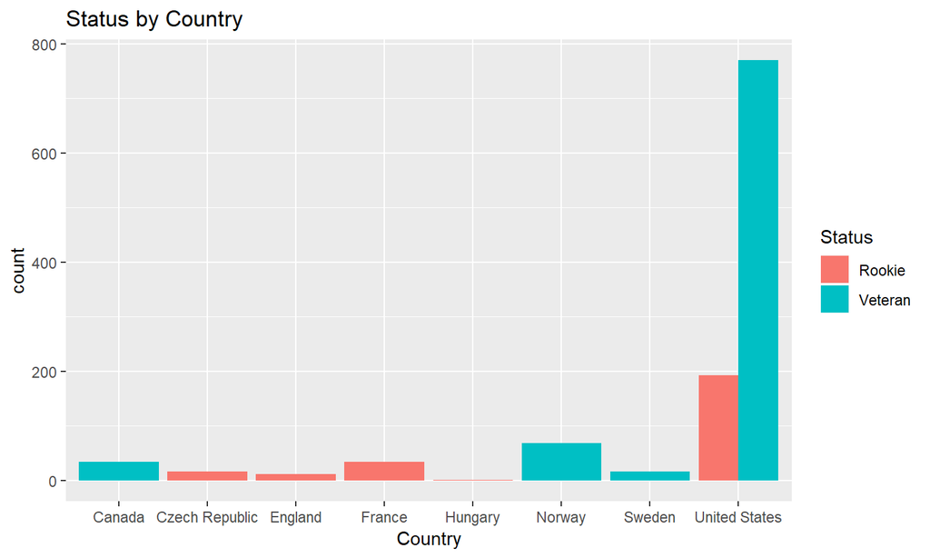

This graph shows the country and status of Iditarod participants.

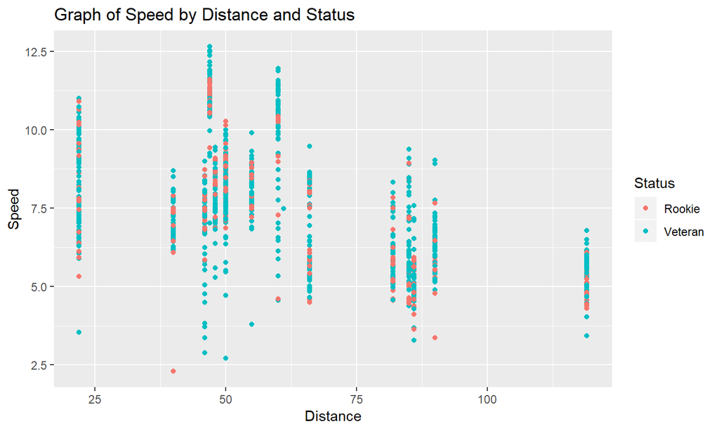

This graph shows the distance and speed of Iditarod participants by their status.

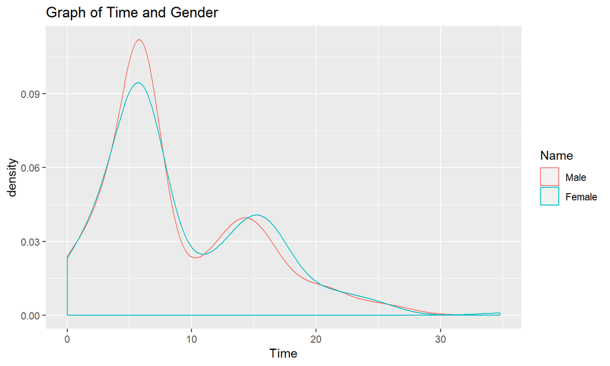

This graph shows the density plot of time for Iditarod partcipants by gender.

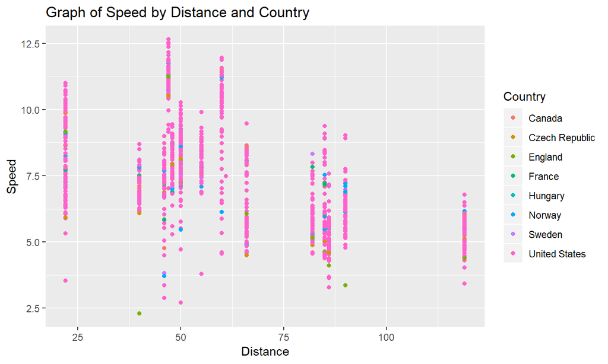

This graph shows the speed and distance of Iditarod participants by their country.

## Final Model - Random Forest - Mean Impute - Dummy Encoding

```
##  Accuracy
## 0.8967742
```

```
## Balanced Accuracy
##         0.8118921
```